# Machine Learning Assignment

R G

July 25, 2015

## Overview

The purpose of this analysis is to use data from accelerometers on a bell, forearm, arm and dumbbell of six participant to predict how well the participant do barbell lifts in 5 different ways. the outcome will be the variable **classe**, class A corresponds to the specified execution of the exercise, while the other 4 classes correspond to common mistakes. In order to analyze the correlation between the different groups of variables, we need to install **corrplot** package

## Data Preparation

we download the training and test data from the repository

## Predictors Selection

Eliminate columns with zero variance or too many NA or empty values, as a result we reduce the number of variables from 160 to 53

we divide the variables in groups and check the correlation between them

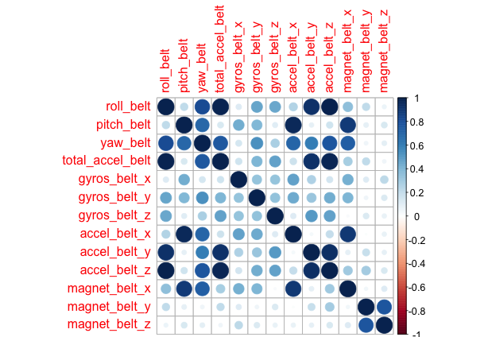

belt is the sensor were more variables are correlated, afte the same analysis for all the sensor, this is the list of the final variables

```
##  [1] "X"                    "user_name"            "roll_belt"
##  [4] "pitch_belt"           "yaw_belt"             "gyros_belt_x"
##  [7] "gyros_belt_y"         "gyros_belt_z"         "magnet_belt_x"
## [10] "magnet_belt_y"        "magnet_belt_z"        "roll_arm"
## [13] "pitch_arm"            "yaw_arm"              "total_accel_arm"
## [16] "gyros_arm_x"          "gyros_arm_z"          "accel_arm_x"
## [19] "accel_arm_y"          "accel_arm_z"          "magnet_arm_x"
## [22] "magnet_arm_y"         "magnet_arm_z"         "roll_dumbbell"
## [25] "pitch_dumbbell"       "yaw_dumbbell"         "total_accel_dumbbell"
## [28] "gyros_dumbbell_x"     "gyros_dumbbell_y"     "accel_dumbbell_x"
## [31] "accel_dumbbell_y"     "accel_dumbbell_z"     "magnet_dumbbell_x"
## [34] "magnet_dumbbell_y"    "magnet_dumbbell_z"    "roll_forearm"
## [37] "pitch_forearm"        "yaw_forearm"          "gyros_forearm_x"
## [40] "gyros_forearm_y"      "gyros_forearm_z"      "accel_forearm_x"
## [43] "accel_forearm_y"      "accel_forearm_z"      "magnet_forearm_x"
## [46] "magnet_forearm_y"     "magnet_forearm_z"     "classe"
```

## Modeling

The choose algorith for the model is **regression and classification tree**

```r
modelFit.lm <- train( classe ~ ., method = "rpart", data=pml.training.clean)
print(modelFit.lm)
```

```
## CART
##
## 19622 samples
##    47 predictor
##     5 classes: 'A', 'B', 'C', 'D', 'E'
##
## No pre-processing
## Resampling: Bootstrapped (25 reps)
##
## Summary of sample sizes: 19622, 19622, 19622, 19622, 19622, 19622, ...
##
## Resampling results across tuning parameters:
##
##   cp         Accuracy   Kappa      Accuracy SD  Kappa SD
##   0.2436975  0.7363363  0.6650789  0.08901664   0.1135718
##   0.2568722  0.5780237  0.4617625  0.09343943   0.1206293
##   0.2704031  0.3829192  0.1702030  0.09566917   0.1669158
##
## Accuracy was used to select the optimal model using  the largest value.
## The final value used for the model was cp = 0.2436975.
```

```r
print(modelFit.lm$finalModel)
```

```
## n= 19622
##
## node), split, n, loss, yval, (yprob)
##       * denotes terminal node
##
## 1) root 19622 14042 A (0.28 0.19 0.17 0.16 0.18)
##   2) X< 5580.5 5580     0 A (1 0 0 0 0) *
##   3) X>=5580.5 14042 10245 B (0 0.27 0.24 0.23 0.26)
##     6) X< 9377.5 3797     0 B (0 1 0 0 0) *
##     7) X>=9377.5 10245  6638 E (0 0 0.33 0.31 0.35) *
```

[figure not shown]

```r
# plot(modelFit.lm$finalModel, uniform = TRUE, main="Classification Tree", cex = .8)
# text(modelFit.lm$finalModel, use.n = TRUE, all = TRUE, cex = .7)
```

```r
#predict.lm <- predict(modelFit.lm, newdata = pml.testing)
```